# 6 CFA: Basics

2020-12-19

## Confirmatory Factor Analysis Practice Assignment

In the section below, you should load the `lavaan` and `semPlot` libraries. The data is included in `assignment_cfabasics.csv`, and you should load that dataset.

```r
library(lavaan)
```

```r
library(semPlot)
data = read.csv("assignment_cfabasics.csv")
```

## The Data

The data represents a 30-item questionnaire called CAAFI: Computer Aversion, Attitudes, and Familiarity Index. This questionnaire includes items on computer usage, attitudes, and familiarity.

- Computer Familiarity: Items 3, 13-14, 16, 20-23, 27, and 30.
- Computer Attitudes: Items 1-2, 4-5, 8, 11, 18-19, and 28-29.
- Computer Aversion: Items 6-7, 9-10, 12, 15, 17, and 24-26.

Here are the items that are present on the survey:

1. I enjoy using computers.
2. Being able to use a computer is important to me.
3. I keep up with the latest computer hardware.
4. Computers are beneficial because they save people time.
5. I like using word-processing programs.
6. I feel like a fool when I am using a computer and others are around.
7. I am smart enough to use a computer.
8. I avoid using computers whenever possible.
9. I do not understand how to use computer software (e.g., word-processing programs, spreadsheet programs, etc.).
10. I feel that I understand how to use computer files, documents, and folders.
11. I use a computer input device every day (e.g., a keyboard, a touch pad, a mouse).
12. I can use a computer to successfully perform tasks.
13. I can add new hardware to a computer.
14. I enjoy reading computer magazines.
15. When I use a computer, I am afraid that I will damage it.
16. I enjoy connecting new computer accessories.
17. I must have a reference manual or a help file to run computer software.
18. E-mail is an easy way to communicate with people.
19. I use e-mail every day.
20. I am comfortable changing (installing/upgrading) computer software.
21. I often read computer books.
22. My friends often ask me computer-related questions.
23. I often read computer magazines.
24. Overall, I feel that I don’t know how to use a computer.
25. Computers are too scientific for me.
26. When using a computer, I often lose data.
27. I enjoy learning to use new software programs.
28. I like to use computer input devices such as a keyboard, a touch pad, a mouse, etc.
29. Using a computer is entertaining.
30. I keep up with the latest computer software.

## Build a Model

In this section, create a one-factor model of all of the items together.

```r
# x = seq(1, 30)
# for (val in x){
#   cat(paste("q",val, sep = ""), "+ ")
# }

one.model = '
computer =~ q1 + q2 + q3 + q4 + q5 + q6 + q7 + q8 + q9 + q10 + q11 + q12 + q13 + q14 + q15 + q16 + q17 + q18 + q19 + q20 + q21 + q22 + q23 + q24 + q25 + q26 + q27 + q28 + q29 + q30
'
```

In this section, create a three-factor model based on the items proposed grouping listed above.

```r
# - Computer Familiarity: Items 3, 13-14, 16, 20-23, 27, and 30.
# - Computer Attitudes: Items 1-2, 4-5, 8, 11, 18-19, and 28-29.
# - Computer Aversion: Items 6-7, 9-10, 12, 15, 17, and 24-26.

three.model = '
familiarity =~ q3 + q13 + q14 + q16 + q20 + q21 + q22 + q23 + q27 + q30
attitudes =~ q1 + q2 + q4 + q5 + q8 + q11 + q18 + q19 + q28 + q29
aversion =~ q6 + q7 + q9 + q10 + q12 + q15 + q17 + q24 + q25 + q26
'
```

## Analyze Your Model

Analyze both the one-factor and three-factor model.

```r
one.model.fit = cfa(one.model, data = data)
three.model.fit = cfa(three.model, data = data)
```

## Summarize Your Model

Include a summary of the one-factor and three-factor model with standardized output, rsquare values, and fit.measures.

```r
summary(one.model.fit, standardize = T, rsquare = T, fit.measures = T)
```

```
## lavaan 0.6-7 ended normally after 39 iterations
##
##   Estimator                                         ML
##   Optimization method                           NLMINB
##   Number of free parameters                         60
##
##   Number of observations                           794
##
## Model Test User Model:
##
##   Test statistic                              4486.874
##   Degrees of freedom                               405
##   P-value (Chi-square)                           0.000
##
## Model Test Baseline Model:
##
##   Test statistic                              9851.068
##   Degrees of freedom                               435
##   P-value                                        0.000
##
## User Model versus Baseline Model:
##
##   Comparative Fit Index (CFI)                    0.566
##   Tucker-Lewis Index (TLI)                       0.534
##
## Loglikelihood and Information Criteria:
##
##   Loglikelihood user model (H0)             -37351.422
##   Loglikelihood unrestricted model (H1)     -35107.985
##
##   Akaike (AIC)                               74822.843
##   Bayesian (BIC)                             75103.468
##   Sample-size adjusted Bayesian (BIC)        74912.936
##
## Root Mean Square Error of Approximation:
##
##   RMSEA                                          0.113
##   90 Percent confidence interval - lower         0.110
##   90 Percent confidence interval - upper         0.116
##   P-value RMSEA <= 0.05                          0.000
```

[output cut: 96 more lines]

```
##     q16               0.264
##     q17               0.109
##     q18               0.116
##     q19               0.099
##     q20               0.421
##     q21               0.030
##     q22               0.221
##     q23               0.053
##     q24               0.390
##     q25               0.326
##     q26               0.205
##     q27               0.264
##     q28               0.314
##     q29               0.346
##     q30               0.307
```

```r
summary(three.model.fit, standardize = T, rsquare = T, fit.measures = T)
```

```
## lavaan 0.6-7 ended normally after 45 iterations
##
##   Estimator                                         ML
##   Optimization method                           NLMINB
##   Number of free parameters                         63
##
##   Number of observations                           794
##
## Model Test User Model:
##
##   Test statistic                              2874.750
##   Degrees of freedom                               402
##   P-value (Chi-square)                           0.000
##
## Model Test Baseline Model:
##
##   Test statistic                              9851.068
##   Degrees of freedom                               435
##   P-value                                        0.000
##
## User Model versus Baseline Model:
##
##   Comparative Fit Index (CFI)                    0.737
##   Tucker-Lewis Index (TLI)                       0.716
##
## Loglikelihood and Information Criteria:
##
##   Loglikelihood user model (H0)             -36545.359
##   Loglikelihood unrestricted model (H1)     -35107.985
##
##   Akaike (AIC)                               73216.719
##   Bayesian (BIC)                             73511.375
##   Sample-size adjusted Bayesian (BIC)        73311.316
##
## Root Mean Square Error of Approximation:
##
##   RMSEA                                          0.088
##   90 Percent confidence interval - lower         0.085
##   90 Percent confidence interval - upper         0.091
##   P-value RMSEA <= 0.05                          0.000
```

[output cut: 108 more lines]

```
##     q11               0.214
##     q18               0.153
##     q19               0.138
##     q28               0.411
##     q29               0.444
##     q6                0.388
##     q7                0.342
##     q9                0.244
##     q10               0.445
##     q12               0.450
##     q15               0.225
##     q17               0.161
##     q24               0.541
##     q25               0.466
##     q26               0.299
```

## Diagram Your Model

Include a diagram for the three-factor model. Use the `what` and `edge.color` arguments to denote the strongest paths.

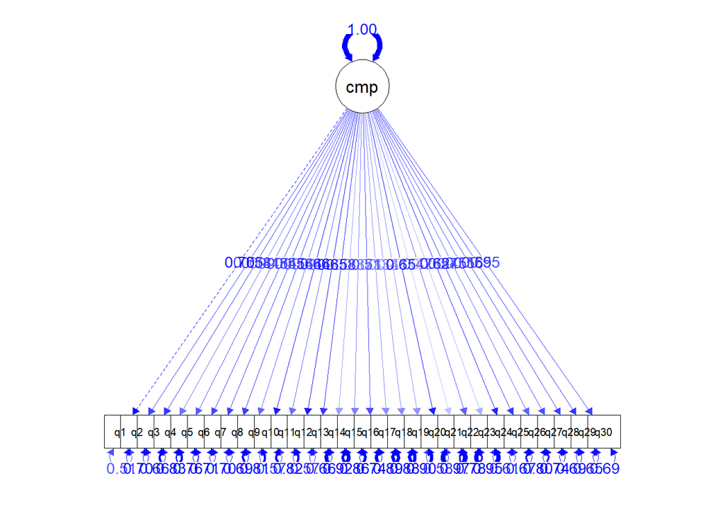

```r
semPaths(one.model.fit, whatLabels = "std", what = "std", edge.color = "blue", edge.label.cex = 1)
```

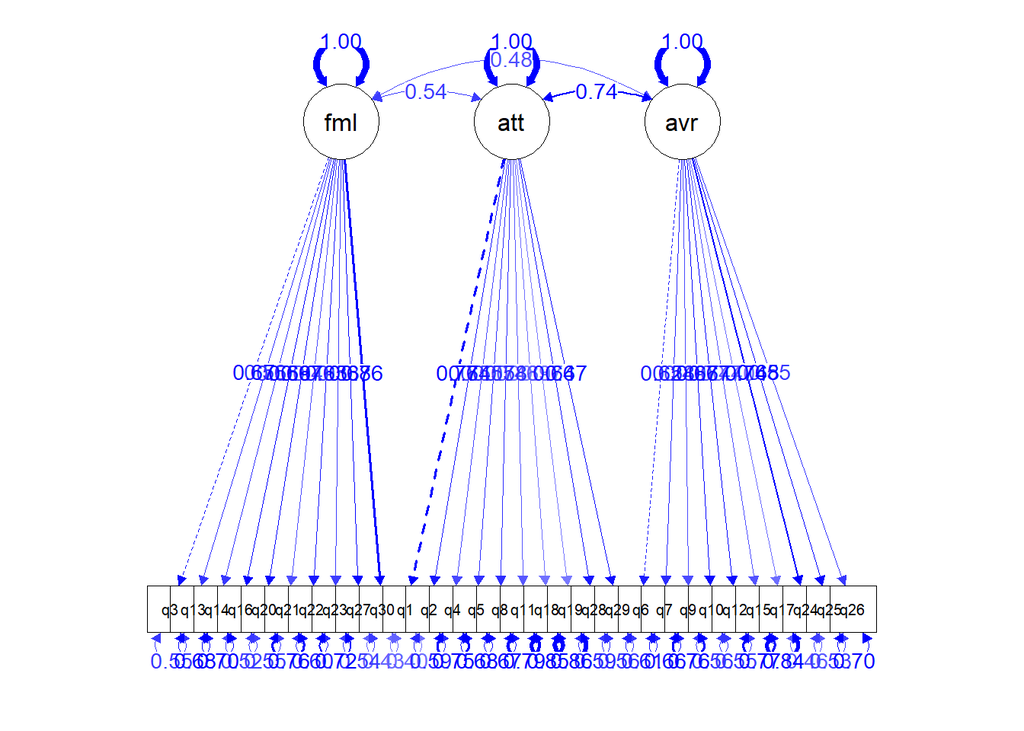

```r
semPaths(three.model.fit, whatLabels = "std", what = "std", edge.color = "blue", edge.label.cex = 1)
```

## Compare Models

Use the `anova()` function and the `fitmeasures()` to create a model comparison.

```r
anova(one.model.fit, three.model.fit)
```

```
## Chi-Squared Difference Test
##
##                  Df   AIC   BIC  Chisq Chisq diff Df diff Pr(>Chisq)
## three.model.fit 402 73217 73511 2874.7
## one.model.fit   405 74823 75103 4486.9     1612.1       3  < 2.2e-16 ***
## ---
## Signif. codes:  0 '***' 0.001 '**' 0.01 '*' 0.05 '.' 0.1 ' ' 1
```

```r
fitmeasures(one.model.fit)
```

```
##                npar                fmin               chisq                  df
##              60.000               2.825            4486.874             405.000
##              pvalue      baseline.chisq         baseline.df     baseline.pvalue
##               0.000            9851.068             435.000               0.000
##                 cfi                 tli                nnfi                 rfi
##               0.566               0.534               0.534               0.511
##                 nfi                pnfi                 ifi                 rni
##               0.545               0.507               0.568               0.566
##                logl   unrestricted.logl                 aic                 bic
##          -37351.422          -35107.985           74822.843           75103.468
##              ntotal                bic2               rmsea      rmsea.ci.lower
##             794.000           74912.936               0.113               0.110
##      rmsea.ci.upper        rmsea.pvalue                 rmr          rmr_nomean
##               0.116               0.000               0.243               0.243
##                srmr        srmr_bentler srmr_bentler_nomean                crmr
##               0.107               0.107               0.107               0.111
##         crmr_nomean          srmr_mplus   srmr_mplus_nomean               cn_05
##               0.111               0.107               0.107              81.149
##               cn_01                 gfi                agfi                pgfi
##              84.903               0.632               0.578               0.551
##                 mfi                ecvi
##               0.077               5.802
```

```r
fitmeasures(three.model.fit)
```

```
##                npar                fmin               chisq                  df
##              63.000               1.810            2874.750             402.000
##              pvalue      baseline.chisq         baseline.df     baseline.pvalue
##               0.000            9851.068             435.000               0.000
##                 cfi                 tli                nnfi                 rfi
##               0.737               0.716               0.716               0.684
##                 nfi                pnfi                 ifi                 rni
##               0.708               0.654               0.738               0.737
##                logl   unrestricted.logl                 aic                 bic
##          -36545.359          -35107.985           73216.719           73511.375
##              ntotal                bic2               rmsea      rmsea.ci.lower
##             794.000           73311.316               0.088               0.085
##      rmsea.ci.upper        rmsea.pvalue                 rmr          rmr_nomean
##               0.091               0.000               0.168               0.168
##                srmr        srmr_bentler srmr_bentler_nomean                crmr
##               0.087               0.087               0.087               0.090
##         crmr_nomean          srmr_mplus   srmr_mplus_nomean               cn_05
##               0.090               0.087               0.087             125.220
##               cn_01                 gfi                agfi                pgfi
##             131.059               0.782               0.748               0.676
##                 mfi                ecvi
##               0.211               3.779
```

QUESTION: Which model is better? ANSWER: 3 factor model is better. Its loadings and fitindicies are better.

## Clean Output

QUESTION: Looking at the item loadings, are any of the items poor (i.e., they do not strongly relate to their factor)? ANSWER: There are a few bad one. Overall they form a okay model. Scores aren’t that high but not too bad either.

```r
correl = residuals(three.model.fit, type = "cor")
correl$cov
```

```
##     q3     q13    q14    q16    q20    q21    q22    q23    q27    q30
## q3   0.000
## q13  0.049  0.000
## q14 -0.083 -0.069  0.000
## q16 -0.083 -0.029  0.010  0.000
## q20 -0.001  0.182 -0.129 -0.003  0.000
## q21 -0.081 -0.133  0.345  0.002 -0.136  0.000
## q22 -0.011 -0.008 -0.026  0.026  0.005  0.032  0.000
## q23 -0.105 -0.121  0.456 -0.004 -0.147  0.468  0.007  0.000
## q27 -0.100 -0.059 -0.015  0.135  0.005 -0.017  0.031 -0.014  0.000
## q30  0.186 -0.028 -0.059 -0.040  0.022 -0.048 -0.030 -0.055 -0.017  0.000
## q1   0.154  0.143 -0.054  0.004  0.093 -0.107  0.009 -0.071  0.066  0.029
## q2   0.160  0.053 -0.097 -0.020 -0.010 -0.110 -0.032 -0.096 -0.036 -0.019
## q4   0.059  0.028 -0.099 -0.036 -0.031 -0.099 -0.066 -0.112 -0.053 -0.043
## q5   0.071  0.044 -0.088 -0.037  0.027 -0.107 -0.005 -0.141  0.004 -0.021
## q8   0.037  0.103 -0.147 -0.070  0.064 -0.232 -0.037 -0.207 -0.063 -0.043
## q11  0.003  0.054 -0.135 -0.087  0.038 -0.192 -0.077 -0.179 -0.048 -0.070
## q18 -0.005  0.001 -0.087 -0.053  0.002 -0.177 -0.095 -0.140 -0.088 -0.013
## q19  0.050 -0.009 -0.088 -0.092  0.029 -0.127 -0.064 -0.116 -0.041  0.000
## q28  0.020  0.054  0.003  0.107  0.094 -0.084  0.007 -0.052  0.140  0.019
## q29  0.042  0.046 -0.005  0.089  0.062 -0.108  0.002 -0.038  0.136  0.053
## q6   0.009  0.110 -0.132  0.002  0.112 -0.092  0.012 -0.109  0.030 -0.040
## q7   0.085  0.170 -0.112  0.031  0.163 -0.109  0.008 -0.084  0.000  0.001
## q9   0.054  0.134 -0.104  0.000  0.154 -0.119  0.051 -0.116  0.049  0.025
## q10  0.108  0.227 -0.035  0.107  0.236 -0.125  0.041 -0.048  0.084  0.064
## q12  0.076  0.202 -0.127  0.004  0.141 -0.176  0.016 -0.166 -0.030 -0.039
## q15 -0.036  0.019 -0.095 -0.104  0.055 -0.141 -0.057 -0.144 -0.044 -0.082
## q17 -0.014  0.141 -0.063  0.003  0.131 -0.162  0.048 -0.119 -0.042 -0.044
## q24  0.026  0.121 -0.173 -0.054  0.134 -0.244  0.004 -0.198 -0.075 -0.040
## q25  0.030  0.108 -0.111 -0.036  0.142 -0.193 -0.002 -0.154 -0.021 -0.018
## q26  0.002  0.097 -0.138  0.000  0.114 -0.227 -0.038 -0.198 -0.032 -0.066
##     q1     q2     q4     q5     q8     q11    q18    q19    q28    q29
## q3
## q13
## q14
## q16
## q20
## q21
## q22
## q23
```

[output cut: 38 more lines]

```
## q11
## q18
## q19
## q28
## q29
## q6   0.000
## q7   0.028  0.000
## q9   0.039 -0.016  0.000
## q10 -0.064  0.049  0.066  0.000
## q12 -0.059  0.031 -0.009  0.082  0.000
## q15  0.098 -0.026 -0.004 -0.115 -0.041  0.000
## q17  0.020 -0.019  0.013 -0.046 -0.044  0.070  0.000
## q24  0.002 -0.028 -0.004 -0.025 -0.032  0.013  0.006  0.000
## q25  0.028 -0.043 -0.018 -0.045 -0.086  0.077  0.056  0.080  0.000
## q26  0.008 -0.048 -0.014 -0.030 -0.022  0.078  0.095  0.005  0.065  0.000
```

## Modifications

Include the potential modification indices for the three-factor model. Be sure to use the `sort` option to see the strongest modification indices.

```r
modindices(three.model.fit, sort. = T)
```

```
##             lhs op rhs      mi    epc sepc.lv sepc.all sepc.nox
## 188         q14 ~~ q23 372.213  1.328   1.328    0.729    0.729
## 263         q21 ~~ q23 354.038  1.026   1.026    0.704    0.704
## 186         q14 ~~ q21 199.669  0.933   0.933    0.531    0.531
## 135          q3 ~~ q30 175.669  0.810   0.810    0.577    0.577
## 471         q18 ~~ q19 116.303  0.463   0.463    0.393    0.393
## 112    aversion =~ q21  92.803 -0.599  -0.530   -0.389   -0.389
## 111    aversion =~ q20  92.227  0.675   0.597    0.344    0.344
## 158         q13 ~~ q20  87.275  0.641   0.641    0.369    0.369
## 121    aversion =~  q8  81.038  0.668   0.590    0.516    0.516
## 215         q16 ~~ q27  70.520  0.591   0.591    0.349    0.349
## 101   attitudes =~ q12  69.952  0.457   0.330    0.451    0.451
## 92    attitudes =~ q21  69.441 -0.671  -0.485   -0.356   -0.356
## 108    aversion =~ q13  68.628  0.596   0.527    0.321    0.321
## 114    aversion =~ q23  67.516 -0.533  -0.471   -0.325   -0.325
```

[output cut: 481 more lines]